# Electornic supplemnt: A Seismologically Consistent Surface Rupture Length Model for Unbounded and Width-Limited Events

G. Lavrentiadis, UCLA & Caltech Y. Wang, USC N.A. Abrahamson, UC Berkeley Y. Bozorgnia, UCLA C. Goulet, USC

2022-10-31

## Introduction

This study presents a new $SRL$ model with physically defensible scaling for unbounded and width-limited ruptures.

Study Objectives:

- Consistent scaling with seismological theory
- Captures scaling for width-limited ruptures

## Load Data

The empirical data that are used in model development include the FDHI (Sarmiento et al. 2021), Wells and Coppersmith (1994), and Baize et al. (2020) datasets. The surface rupture lengths ($SRL$) of the events in FDHI dataset are computed based on the Event Coordinate System (ECS), while the $SRL$ in Wells and Coppersmith (1994) and Baize et al. (2020) are reported directly. Additionally, dynamic rupture simulations performed by SCEC are used to derive the rupture width model for the width-limited ruptures.

```r
#read srl flatfiles
#FDHI
df_FDHI_srl_all <- read.csv(fname_FDHI_srl)

#FDHI processing
#create normal and reverse fault flags
df_FDHI_srl_all$FN <- pmax(-df_FDHI_srl_all$sof, 0)
df_FDHI_srl_all$FR <- pmax( df_FDHI_srl_all$sof, 0)
df_FDHI_srl_all$FD <- abs(  df_FDHI_srl_all$sof )
#style of faulting name
df_FDHI_srl_all$style2                         <- 'Strike-Slip'
df_FDHI_srl_all[df_FDHI_srl_all$FN>0,'style2'] <- 'Normal'
df_FDHI_srl_all[df_FDHI_srl_all$FR>0,'style2'] <- 'Reverse'
#fault width
df_FDHI_srl_all$seis_width <- df_FDHI_srl_all$seis_depth / sin(deg2rad(df_FDHI_srl_all$dip))

#SCEC
#read srl flatfiles
df_SCEC_srl_original  <- read.csv(fname_SCEC_srl_original)
df_SCEC_srl_low_width <- read.csv(fname_SCEC_srl_low_width)
df_SCEC_srl_const_sig <- read.csv(fname_SCEC_srl_const_sig)
df_SCEC_srl_sim_2     <- read.csv(fname_SCEC_srl_sim2)
df_SCEC_srl_sim_3     <- read.csv(fname_SCEC_srl_sim3)
df_SCEC_srl_sim_4     <- read.csv(fname_SCEC_srl_sim4)

#SCEC processing
#define seimogenic depths
df_SCEC_srl_original$seis_depth  <- 20
df_SCEC_srl_low_width$seis_depth <- 15
df_SCEC_srl_const_sig$seis_depth <- 20
df_SCEC_srl_sim_2$seis_depth     <- 20
df_SCEC_srl_sim_3$seis_depth     <- 20
df_SCEC_srl_sim_4$seis_depth     <- 20
#merged data-frame of different simulations
df_SCEC_srl <- bind_rows( df_SCEC_srl_original, df_SCEC_srl_low_width, df_SCEC_srl_const_sig,
                          df_SCEC_srl_sim_2, df_SCEC_srl_sim_3, df_SCEC_srl_sim_4)
#identify width limited events
df_SCEC_srl$flag_wlim <- FALSE
df_SCEC_srl[df_SCEC_srl$wef >= df_SCEC_srl$seis_depth-2.5,'flag_wlim'] <- TRUE
rm(list=c('df_SCEC_srl_original','df_SCEC_srl_low_width','df_SCEC_srl_const_sig',
          'df_SCEC_srl_sim_2', 'df_SCEC_srl_sim_3', 'df_SCEC_srl_sim_4'))
```

The maximum fault width of the empirical data was calculated based on the thickness of the seismogenic zone ($D_{seis}$) and fault dip angle ($\theta$). Table 1 summarizes $D_{seis}$ based on the fault location and Table 2 summarizes $\theta$ for different styles of faulting.
$$W_{lim} = \frac{D_{seis}}{\sin(\theta)}$$
$W_{lim}$ is the maximum width, a rupture can reach before it becomes width limited.

Table 1. Seismogenic Zone Thickness for Differnt Regions

| Region | Seismogenic Depth (km) |
| --- | --- |
| California | 15 |
| Guatemala | 15 |
| New Zealand | 15 |
| Indonesia | 15 |
| Japan | 17 |
| Himalayan Region | 30 |
| Australia | 40 |
| Other | 22 |

Table 2. Dip Angles for Differnt Styles of Faulting

| Style of Fauling | Dip Angle (deg) |
| --- | --- |
| Strike-Slip | 90 |
| Normal | 60 |
| Reverse | 45 |

### Outliers

The following events were excluded from the regression dataset:

- Events less than $\mathbf{M}~5$
- 1892 Laguna Salada: it was occurred in 1892 but mapped in the 2010s. Magnitude is estimated.
- 1978 IzuOshima: surface is incomplete, rupture probably extended offshore to southeast; epicenter is offshore ~17 km
- 1993 Killari: it occurred in a stable continental region; probably a lot of deformation accommodated via folding/warping that was unmapped

```r
#events for regression
df_FDHI_srl <- df_FDHI_srl_all
#remove outliers
df_FDHI_srl  <- subset(df_FDHI_srl, !is.na(event_len) & flag_missing==0 & flag_multiple==0 )
#1892 Laguna Salada
df_FDHI_srl  <- subset(df_FDHI_srl, !(EQ_ID==40 & FLT_ID==1))
#1978 IzuOshima
df_FDHI_srl  <- subset(df_FDHI_srl, !(EQ_ID==62 & FLT_ID==1))
#1993 Killari
df_FDHI_srl  <- subset(df_FDHI_srl, !(EQ_ID==74 & FLT_ID==1))
#2010 Pisayambo
df_FDHI_srl <- subset(df_FDHI_srl,  !(EQ_ID==58 & FLT_ID==1))
#
df_FDHI_srl <- subset(df_FDHI_srl,  !(EQ_ID==52 & FLT_ID==2))
#
df_FDHI_srl <- subset(df_FDHI_srl,  !(EQ_ID==6 & FLT_ID==3))


#remove mag less than 5
df_FDHI_srl  <- subset(df_FDHI_srl, magnitude>=5)

#summarize all outliers
df_FDHI_srl_out <- subset(df_FDHI_srl_all,!(rownames(df_FDHI_srl_all)%in%rownames(df_FDHI_srl)))
```

### Summary datasets

Summary statistics of the empirical dataset are presented below:

```
## Number of Events per dataset:
##           Total: 121
##           FDHA: 64
##           W&C: 51
##           Baize: 6
```

```
## Number of Events per Style of Faulting:
##           Strike-slip: 63
##           Normal: 26
##           Reverse: 32
```

```
## Magnitude Range:
##           maximum: 8.0
##           minimum: 5.0
```

```
## Rupture-Length Range:
##           maximum: 432.0
##           minimum: 1.1
```

Figure 1 shows the Magnitude - Surface rupture length ($\mathbf{M} - SRL$) distribution of the empirical dataset.

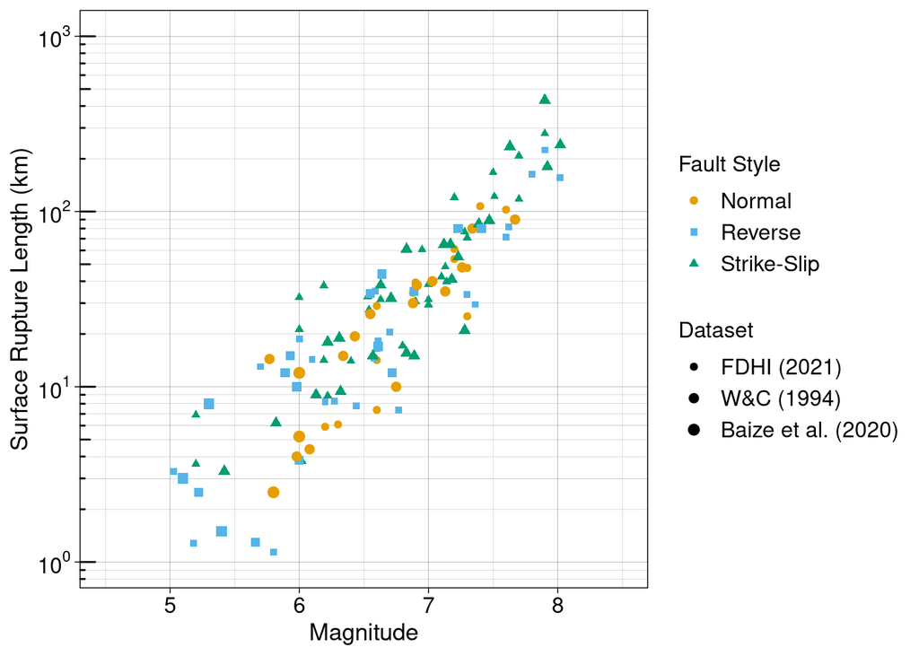

Figure 1. Magnitude - SRL distribution of selected empirical data

Summary statistics of the SCEC simulations are presented below:

```
## Total number of simulations: 554
```

```
## Magnitude Range:
##           maximum: 8.2
##           minimum: 4.9
```

```
## Rupture-Length Range:
##           maximum: 655.2
##           minimum: 1.0
```

Figure 2 compares the $\mathbf{M} - SRL$ distribution of empirical data and SCEC simulations. The two datasets show similar scaling supporting that the scaling relationships derived from the SCEC simulations are applicable to the empirical data.

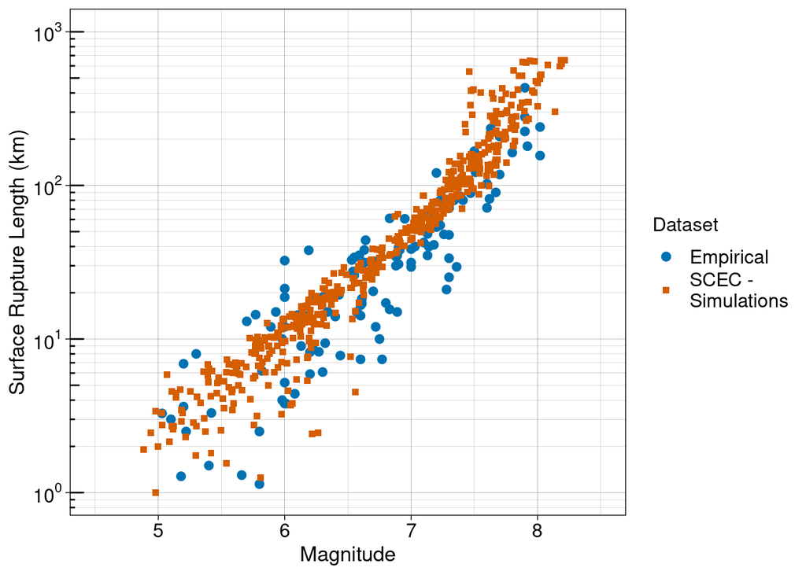

Figure 2. Comparison of Magnitude - SRL distribution of empirical data and SCEC simulations

## Model Development

### Rupture Width Modeling Based on SCEC Simulations

The SCEC simulations were used to develop a Magnitude - Rupture width model for unbounded and width-limited ruptures. Two models were evaluated: (i) a linear model between $W - \mathbf{M}$, hereafter denoted as `model w0`, and (ii) a model with a scaling break at $W_{lim}$, hereafter denoted as `model w1`

The functional form for `model_w0` is:
$$\begin{equation}
\log(W) = \mathbf(M) + \epsilon_W
\end{equation}$$

The functional form for `model_w1` is:
$$\begin{equation}
log(W) = \min(\beta_1 + \beta_2 \mathbf{M}, \log(W_{lim})) + \epsilon_W
\end{equation}$$

```r
## Regression formulas
form_model_w0 <- log10(wef) ~ 1 + magnitude
form_model_w1 <- log10(wef) ~ 1 + magnitude

## Regression
fit_model_w0 <- lm(form_model_w0, data=df_SCEC_srl)
fit_model_w1 <- lm(form_model_w1, data=subset(df_SCEC_srl, !flag_wlim))
```

The $W - \mathbf{M}$ model summary is presented below. `model w1` has a higher log likelihood and lower Akaike information criterion.

```
## Width Modeling
##
##              Model0:
##      LogLik: 641.71
##      AIC: -1277.43
##
##              Model1:
##      LogLik: 889.34
##      AIC: -1772.69
```

The best estimates of the coefficients of the two candidate models are summarized in Table 3.

Table 3. Rupture Width Model Coefficients

|  | Intercept | $\mathbf{M}$ scaling | $\sigma$ |
| --- | --- | --- | --- |
| model_w0 | -0.7603617 | 0.2735708 | 0.0761189 |
| model_w1 | -1.1602315 | 0.3395897 | 0.0544508 |

Figure 3 compares the two candidate models against the SCEC simulations.

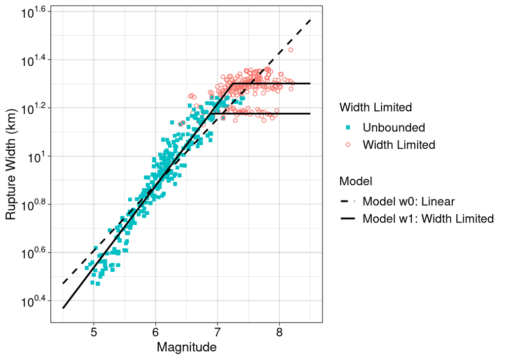

Figure 3. Comparison of candidate rupture width models against the SCEC simulations

The summary of the `model w1` regression is provided below:

```r
summary(fit_model_w1)
```

```
##
## Call:
## lm(formula = form_model_w1, data = subset(df_SCEC_srl, !flag_wlim))
##
## Residuals:
##       Min        1Q    Median        3Q       Max
## -0.123926 -0.033305  0.000471  0.036243  0.172420
##
## Coefficients:
##              Estimate Std. Error t value Pr(>|t|)
## (Intercept) -1.160232   0.032544  -35.65   <2e-16 ***
## magnitude    0.339590   0.005303   64.04   <2e-16 ***
## ---
## Signif. codes:  0 '***' 0.001 '**' 0.01 '*' 0.05 '.' 0.1 ' ' 1
##
## Residual standard error: 0.05445 on 328 degrees of freedom
## Multiple R-squared:  0.9259, Adjusted R-squared:  0.9257
## F-statistic:  4101 on 1 and 328 DF,  p-value: < 2.2e-16
```

Figure 4 shows the scaling of the preferred model (`model w1`) against the SCEC data.

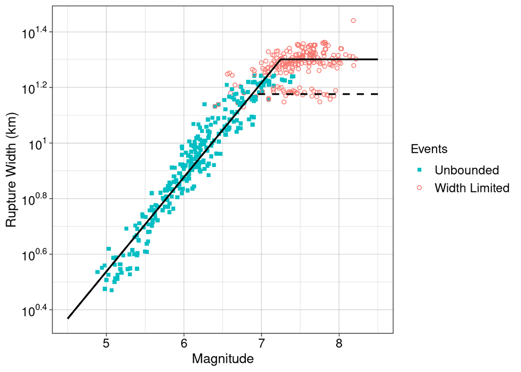

Figure 4. Preferred model for rupture width scaling

Figure 5 shows the residuals of the preferred model versus magnitude.

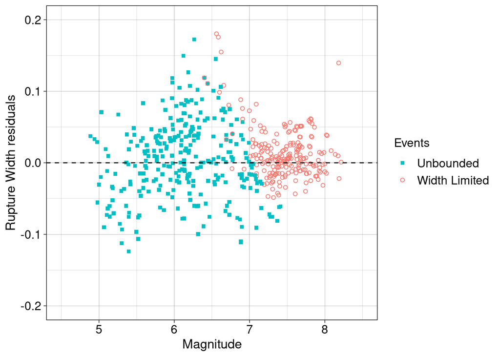

Figure 5. Resisuals of Preferred Rupture Width Model for SCEC simulations

### SRL Model Derivation

This section presents the deviation of the $SRL\sim\mathbf{M}$ functional form. The Seismic Moment ($M_0$) is defined as:

$$\begin{equation}
M_0 = \mu~\bar{D}~L~W
\end{equation}$$

where $\mu$ is the stiffness of the crust, $\bar{D}$ is the average slip on the rupture, $L$ is the length of the rupture, and $W$ is width of the rupture. Taking the log of the previous equation and substituting the definition of the Moment Magnitude ($\mathbf{M} = \frac{2}{3}\log(M_0) - 10.7$) we get:

$$\begin{equation}
\mathbf{M} = \frac{2}{3}\log(\mu) + \frac{2}{3}\log(\bar{D}) +
\frac{2}{3}\log(L) + \frac{2}{3}\log(W) - 10.7
\end{equation}$$

Since stiffness of the crust ($\mu$) is constant, the previous equation simplifies to:

$$\begin{equation}
\mathbf{M} = \frac{2}{3}\log(\bar{D}) + \frac{2}{3}\log(L) +
\frac{2}{3}\log(W) + c
\end{equation}$$

where $c$ is used to denote any arbitrary constant.

Three commonly used scaling models for the average displacements found in the literature include the $\sqrt{A}$ model, hereafter called `model 1`, the $W$ model, hereafter called `model 2`, and the $L$ model, hereafter called `model 3` (Scholz, 1982; Romanowicz, 1992; Romanowicz and Rundle, 1993; Romanowicz, 1994; Scholz, 1994; Bodin and Brune, 1996; Pegler and Das, 1996; Scholz, 1997, 1998; Hanks and Bakun, 2002; Leonard, 2010).

For `model 1`, the average displacement is assumed to scale linearly with the square root of the rupture area:

$$\begin{equation}
\bar{D} = c \sqrt{A} = c \sqrt{L~W}
\end{equation}$$

For `model 2`, the average displacement is assumed to scale linearly with the width of the rupture:

$$\begin{equation}
\bar{D} = c W
\end{equation}$$

while for `model 3`, the average displacement is assumed to scale linearly with the length of the rupture:

$$\begin{equation}
\bar{D} = c L
\end{equation}$$

Using `model 1` the $\mathbf{M}$ scaling relationship becomes:
$$\begin{equation}
\mathbf{M} = \log(L) + \log(W) + c
\end{equation}$$
with `model 2` the $\mathbf{M}$ scaling relationship becomes:
$$\begin{equation}
\mathbf{M} = \frac{2}{3}\log(L) + \frac{4}{3}\log(W) + c
\end{equation}$$
and with `model 3` the $\mathbf{M}$ scaling relationship becomes:
$$\begin{equation}
\mathbf{M} = \frac{4}{3}\log(L) + \frac{2}{3}\log(W) + c
\end{equation}$$

Solving for $\log(L)$ in previous equations `model 1` becomes:
$$\begin{equation}
\log(L) = \mathbf{M} - \log(W) + c
\end{equation}$$
`model 2` becomes:
$$\begin{equation}
\log(L) = \frac{3}{2} \mathbf{M} - 2 \log(W) + c
\end{equation}$$
and `model 3` becomes:
$$\begin{equation}
\log(L) = \frac{3}{4} \mathbf{M} - \frac{1}{2} \log(W) + c
\end{equation}$$

An additional two candidate models are developed which follow $\sqrt{A}$ scaling for unbounded ruptures and transition to $L$ and $W$ scaling, respectively, for width-limited events. The two models are referred to as `model 2'` and `model 3'` and their functional forms are provided next. The `model 2'` functional form is:
$$\begin{equation}
\log(L) = \begin{cases} \mathbf{M} - \log(W) + c & \mathbf{M} \le
\mathbf{M}_{lim} \\ \frac{3}{2} \mathbf{M} - 2 \log(W) + c_2' +
c & \mathbf{M} > \mathbf{M}_{lim} \end{cases}
\end{equation}$$
while, the `model 3'` functional form is:
$$\begin{equation}
\log(L) = \begin{cases} \mathbf{M} - \log(W) + c & \mathbf{M} \le
\mathbf{M}_{lim} \\ \frac{3}{4} \mathbf{M} - \frac{1}{2} \log(W) +
c_3' + c & \mathbf{M} > \mathbf{M}_{lim} \end{cases}
\end{equation}$$
$c_2'$ and $c_3'$ are added in order to have a continuous transition between the two branches. The transition from unbounded to width-limited events occurs at $\mathbf{M}_{lim}$, $W_{lim}$ coordinate pair. Solving for $c_2'$ and $c_3'$ at the transition point we get:

$$\begin{equation}
c_2' = -\frac{1}{2} \mathbf{M}_{lim} + \log(W_{lim})
\end{equation}$$
$$\begin{equation}
c_3' = \frac{1}{4} \mathbf{M}_{lim} - \frac{1}{2} \log(W_{lim})
\end{equation}$$
With the estimated coefficients, the previous equations can be simplified. `model 2'` becomes:
$$\begin{equation}
\log(L) = \frac{3}{2} \mathbf{M} - \frac{1}{2}
\min(\mathbf{M},\mathbf{M}_{lim}) - \log(W) + c
\end{equation}$$
and `model 3'` becomes:
$$\begin{equation}
\log(L) = \frac{3}{4} \mathbf{M} + \frac{1}{4}
\min(\mathbf{M},\mathbf{M}_{lim}) - \log(W) + c
\end{equation}$$

Substituting the `model w1` from the SCEC rupture simulations to the `model 1` functional form we get:
$$\begin{equation}
\log(L) = \mathbf{M} - \min(\beta_1 + \beta_2 \mathbf{M}, \log(W_{lim}))
+ c
\end{equation}$$
for `model 2` we get:
$$\begin{equation}
\log(L) = \frac{3}{2} \mathbf{M} - 2 min(\beta_1 + \beta_2 \mathbf{M},
\log(W_{lim})) + c
\end{equation}$$
and for `model 3` we get:
$$\begin{equation}
\log(L) = \frac{3}{4} \mathbf{M} - \frac{1}{2} min(\beta_1 + \beta_2
\mathbf{M}, \log(W_{lim})) + c
\end{equation}$$

Similarly, for `model 2'` we get:
$$\begin{equation}
\log(L) = \frac{3}{2} \mathbf{M} - \frac{1}{2}
\min(\mathbf{M},\mathbf{M}_{lim}) - min(\beta_1 + \beta_2 \mathbf{M},
\log(W_{lim})) + c
\end{equation}$$
and for `model 3'` we get:
$$\begin{equation}
\log(L) = \frac{3}{4} \mathbf{M} + \frac{1}{4}
\min(\mathbf{M},\mathbf{M}_{lim}) - min(\beta_1 + \beta_2 \mathbf{M},
\log(W_{lim})) + c
\end{equation}$$

Assuming the surface to sub-surface rupture length scaling is of the form $\log(SRL) = c_1 \log(L) + c$, substituting it to the previous equations, condensing the constants, and solving for $\log(SRL)$, for `model 1` we get:
$$\begin{equation}
\log(SRL) = c_1 \left( \mathbf{M} - \min(\beta_1 + \beta_2 \mathbf{M},
\log(W_{lim})) \right) + c_2 = c_1 X_1 + c_2
\end{equation}$$
for `model 2` we get:
$$\begin{equation}
\log(SRL) = c_1 \left( \frac{3}{2} \mathbf{M} - 2 \min(\beta_1 + \beta_2
\mathbf{M}, \log(W_{lim})) \right) + c_2 = c_1 X_2 + c_2
\end{equation}$$
for `model 3` we get:
$$\begin{equation}
\log(SRL) = c_1 \left( \frac{3}{4} \mathbf{M} - \frac{1}{2} \min(\beta_1
+ \beta_2 \mathbf{M}, \log(W_{lim})) \right) + c_2 = c_1 X_3 + c_2
\end{equation}$$
for `model 2'` we get:
$$\begin{equation}
\log(SRL) = c_1 \left( \frac{3}{2} \mathbf{M} - \frac{1}{2}
\min(\mathbf{M},\mathbf{M}_{lim}) - \min(\beta_1 + \beta_2 \mathbf{M},
\log(W_{lim})) \right) + c_2 = c_1 X_2' + c_2
\end{equation}$$
and for `model 3'` we get:
$$\begin{equation}
\log(SRL) = c_1 \left( \frac{3}{4} \mathbf{M} + \frac{1}{4}
\min(\mathbf{M},\mathbf{M}_{lim}) - \min(\beta_1 + \beta_2 \mathbf{M},
\log(W_{lim})) \right) + c_2 = c_1 X_3' + c_2
\end{equation}$$

The previous equations can be expressed as linear models with, $X_1 = \mathbf{M} - \min(\beta_1 + \beta_2 \mathbf{M}, \log(W_{lim})$, $X_2 = \frac{3}{2} \mathbf{M} - 2 \min(\beta_1 + \beta_2 \mathbf{M}, \log(W_{lim})$, $X_3 = \frac{3}{4} \mathbf{M} - \frac{1}{2} \min(\beta_1 + \beta_2 \mathbf{M}, \log(W_{lim})$, $X_2' = \frac{3}{2} \mathbf{M} - \frac{1}{2} \min(\mathbf{M},\mathbf{M}_{lim}) - min(\beta_1 + \beta_2 \mathbf{M}, \log(W_{lim}))$, and $X_3' = \frac{3}{4} \mathbf{M} + \frac{1}{4} \min(\mathbf{M},\mathbf{M}_{lim}) - min(\beta_1 + \beta_2 \mathbf{M}, \log(W_{lim}))$.

The effect of the style of faulting is also considered through the use of additive terms to account for differences in the static stress drop. The static stress drop is defined as:
$$\begin{equation}
\Delta \sigma = C \mu \frac{\bar{D}}{L_C}
\end{equation}$$
thus, in log scale, a shift in the stress drop will be accompanied by a linear shift in the average displacement ($\log(\bar{D}) = \log(\Delta \sigma) + const$), which, in turn, will shift the intercept of the $SLR \sim \mathbf{M}$ models
Two modeling approaches were evaluated: (i) a common additive term for dip-slip events ($F_D$), and (ii) separate additive terms for Normal and Reverse faults ($F_N$ and $F_R$). The style of faulting dependence introduced through $F_D$, $F_N$, and $F_R$ acts in addition to the style of faulting dependence introduced by the different dip angles between the different styles of faulting.

The final regression relationship for `model 1` is:
$$\begin{equation}
\log(SRL) = c_1 X_1 + c_2 F_D + c_3
\end{equation}$$
the final regression relationship for `model 2` is:
$$\begin{equation}
\log(SRL) = c_1 X_2 + c_2 F_D + c_3
\end{equation}$$
the final regression relationship for `model 3` is:
$$\begin{equation}
\log(SRL) = c_1 X_3 + c_2 F_D + c_3
\end{equation}$$
the final regression relationship for `model 2'` is:
$$\begin{equation}
\log(SRL) = c_1 X'_2 + c_2 F_D + c_3
\end{equation}$$
the final regression relationship for `model 3'` is:
$$\begin{equation}
\log(SRL) = c_1 X'_3 + c_2 F_D + c_3
\end{equation}$$
and the final regression for separate additive terms with $D \sim \sqrt{A}$ scaling, hereafter denoted as `model 1alt` is:
$$\begin{equation}
\log(SRL) = c_1 X_1 + c_2 F_N + c_3 F_R + c_4
\end{equation}$$

Lastly a Wells and Coppersmith type model was also evaluated, hereafter referred as `model 0`, to investigate the impact of width-limited ruptures on current state-of-practice models.
$$\begin{equation}
\log(SRL) = c_1 \mathbf{M} + c_2 F_D + c_3
\end{equation}$$

The coefficients of the previous equations are estimated through a maximum likelihood regression.

### Surface Rupture Length Modeling Based on Empirical Data

The seven candidate models evaluated in predicting $SRL$ as a function of $\mathbf{M}$ are summarized in Table 4.

Table 4. Candiate Regression Models

| Name | Functional Form | Description |
| --- | --- | --- |
| model 0 | $\log(SLR)\sim 1 + \mathbf{M} + F_D$ | W&C 94 type model |
| model 1 | $\log(SLR)\sim1 + X_1 + F_D$ | $\bar{D} \sim \sqrt{A}$ type model with $F_D$ addative term |
| model 2 | $\log(SLR)\sim 1+X_2 + F_D$ | $\bar{D} \sim {W}$ type model with $F_D$ addative term |
| model 3 | $\log(SLR)\sim 1+X_3 + F_D$ | $\bar{D} \sim {L}$ type model with $F_D$ addative term |
| model 2’ | $\log(SLR)\sim 1+X_{2'} + F_D$ | $\bar{D} \sim \sqrt{A},{W}$ type model with $F_D$ addative term |
| model 3’ | $\log(SLR)\sim 1+X_{3'} + F_D$ | $\bar{D} \sim \sqrt{A},{L}$ type model with $F_D$ addative term |
| model 1 alt | $\log(SLR)\sim1 + X_1 + F_N+F_R$ | $\bar{D} \sim \sqrt{A}$ type model with $F_N$ & $F_R$ addative terms |

The next part shows the definition of the regression functional forms and model fit.

```r
# Rupture Width Modeling
#rupture width coefficients
c1_rw <- df_SCEC_model_width_mag_coeffs['model_w1','intrcp']
c2_rw <- df_SCEC_model_width_mag_coeffs['model_w1','M']
#compute rupture widths
df_FDHI_srl$rup_width_unbnd <- 10^(c1_rw + c2_rw*df_FDHI_srl$magnitude)
df_FDHI_srl$rup_width <- pmin(df_FDHI_srl$rup_width_unbnd, df_FDHI_srl$seis_width)

#transitioning magnitude
df_FDHI_srl$magnitude_lim <- 1/c2_rw * (log10(df_FDHI_srl$seis_width) - c1_rw )

#identify width limited events
df_FDHI_srl$flag_wlim <- FALSE
df_FDHI_srl[df_FDHI_srl$rup_width >= df_FDHI_srl$seis_width,'flag_wlim'] <- TRUE

# SRL Modeling
#scaling parameters
#simple models
df_FDHI_srl$x1 <-     df_FDHI_srl$magnitude -   log10(df_FDHI_srl$rup_width)
df_FDHI_srl$x2 <- 3/2*df_FDHI_srl$magnitude - 2*log10(df_FDHI_srl$rup_width)
df_FDHI_srl$x3 <- 3/4*df_FDHI_srl$magnitude - 1/2*log10(df_FDHI_srl$rup_width)
#composite models
df_FDHI_srl$x2prime <- 3/2*df_FDHI_srl$magnitude - 1/2*pmin(df_FDHI_srl$magnitude,df_FDHI_srl$magnitude_lim) - log10(df_FDHI_srl$rup_width)
df_FDHI_srl$x3prime <- 3/4*df_FDHI_srl$magnitude + 1/4*pmin(df_FDHI_srl$magnitude,df_FDHI_srl$magnitude_lim) - log10(df_FDHI_srl$rup_width)

#standard deviation weights
width_scl <- 0.1
sig_scl   <- 2.
df_FDHI_srl$reg_wt <- ( 1 + (sig_scl-1) * sigmoid( 2.197225 * (log10(df_FDHI_srl$rup_width_unbnd)-log10(df_FDHI_srl$seis_width))/ width_scl ) )^2

## Regression formulas
form_model_srl0m     <- log10(event_len) ~ 1 + magnitude  + FD
form_model_srl1m     <- log10(event_len) ~ 1 + x1         + FD
form_model_srl2m     <- log10(event_len) ~ 1 + x2         + FD
form_model_srl3m     <- log10(event_len) ~ 1 + x3         + FD
form_model_srl2pm    <- log10(event_len) ~ 1 + x2prime    + FD
form_model_srl3pm    <- log10(event_len) ~ 1 + x3prime    + FD
form_model_srl1m_alt <- log10(event_len) ~ 1 + x1         + FN + FR

## Regression
fit_model_srl0m     <- lm(form_model_srl0m,     data=df_FDHI_srl)
fit_model_srl1m     <- lm(form_model_srl1m,     data=df_FDHI_srl, weights=reg_wt)
fit_model_srl2m     <- lm(form_model_srl2m,     data=df_FDHI_srl, weights=reg_wt)
fit_model_srl3m     <- lm(form_model_srl3m,     data=df_FDHI_srl, weights=reg_wt)
fit_model_srl2pm    <- lm(form_model_srl2pm,    data=df_FDHI_srl, weights=reg_wt)
fit_model_srl3pm    <- lm(form_model_srl3pm,    data=df_FDHI_srl, weights=reg_wt)
fit_model_srl1m_alt <- lm(form_model_srl1m_alt, data=df_FDHI_srl, weights=reg_wt)
```

The print out below summarizes the log-likelihood and Akaike Information Criterion (AIC) for the different candidate models, while Table 5 summarizes the estimated coefficients.

From a statistical perspective, `model 1`, `model 2`, and `model 3` have similar good predictive performance, with `model 1` being slightly better. The composite models `model 2'` and `model 3'` have poorer performance, and `model 0` is the worst. `model 0` does not consider the finite thickness of the seismogenic zone showcasing the limitations of a purely empirical model. `model 1` to `model 3'` have a break in the magnitude scaling when the width of the rupture reaches the width of the seismogenic zone allowing them to better fit the data.

```
## SRL Modeling:
##          Model0:
##      LogLik: 3.24
##      AIC: 1.52
##
##          Model1:
##      LogLik: 13.16
##      AIC: -18.33
##
##          Model2:
##      LogLik: 12.95
##      AIC: -17.91
##
##          Model3:
##      LogLik: 11.40
##      AIC: -14.80
##
##          Model2':
##      LogLik: 9.06
##      AIC: -10.11
##
##          Model3':
##      LogLik: 9.01
##      AIC: -10.03
##
##          Model1 alt.:
##      LogLik: 13.20
##      AIC: -16.40
```

```
## Standard Deviations:
##  Model 1:
##      Empirical ratio for std of width limted to unbounded events is: 1.96
##
##          Standard Deviations:
##  Model 2:
##      Empirical ratio for std of width limted to unbounded events is: 1.94
##
##          Standard Deviations:
##  Model 3:
##      Empirical ratio for std of width limted to unbounded events is: 1.88
##
##          Standard Deviations:
##  Model 2':
##      Empirical ratio for std of width limted to unbounded events is: 1.80
##
##          Standard Deviations:
##  Model 3':
##      Empirical ratio for std of width limted to unbounded events is: 1.78
##
##          Standard Deviations:
##  Model 1 alt.:
##      Empirical ratio for std of width limted to unbounded events is: 1.95
```

Table 5. SRL Model Coefficients

|  | Intercept | $\mathbf{M}$ scaling | $X_1$ scaling | $X_2$ scaling | $X_3$ scaling | $X_{2'}$ scaling | $X_{3'}$ scaling | $F_N$ | $F_R$ | $F_D$ | $\sigma$ |
| --- | --- | --- | --- | --- | --- | --- | --- | --- | --- | --- | --- |
| model_srl0 | -2.868470 | 0.6481141 | NA | NA | NA | NA | NA | -0.1708604 | NA | NA | 0.2385565 |
| model_srl1 | -3.851229 | NA | 0.9470797 | NA | NA | NA | NA | -0.1439849 | NA | NA | 0.2527196 |
| model_srl2 | -4.183419 | NA | NA | 0.7163769 | NA | NA | NA | -0.1313205 | NA | NA | 0.2531618 |
| model_srl3 | -3.556837 | NA | NA | NA | 1.122013 | NA | NA | -0.1564226 | NA | NA | 0.2564316 |
| model_srl2p | -3.130772 | NA | NA | NA | NA | 0.8111352 | NA | -0.1209749 | NA | NA | 0.2614503 |
| model_srl3p | -4.178782 | NA | NA | NA | NA | NA | 1.011475 | -0.1672819 | NA | NA | 0.2615404 |
| model_srl1_alt | -3.859310 | NA | 0.9484357 | NA | NA | NA | NA | NA | -0.1522028 | -0.1352612 | 0.2537253 |

From seismological theory, `model 1` to `model 3'` should have unit slopes with respect to the magnitude scaling terms (e.g. $X_1$, $X_2$, $X_3$), if the average displacement in the empirical data follows the assumed scaling law and the subsurface rupture length ($L$) was the response variable. With $SRL$ as a response variable, a magnitude scaling term greater than one would imply that the surface to sub-surface rupture length ratio increases with magnitude while a magnitude scaling term less than one would imply that the surface to sub-surface rupture length ratio decreases with magnitude. Intuitively, a greater than one magnitude scaling term is expected, as for large events, a larger part of the rupture is expected to reach the surface. Considering that, `model 1` with a fixed magnitude scaling slope equal to unity is selected as a preferred model, hereafter called `model1_fxd`. The piece of code shows regression of the preferred model.

```r
## Prefered model
# regression formula
form_model_srl1m_fxd <- log10(event_len) ~ 1 + offset(x1) + FD
# regression
fit_model_srl1m_fxd <- lm(form_model_srl1m_fxd, data=df_FDHI_srl, weights=reg_wt)
#residuals
df_FDHI_srl$srl1m_fxd_res <- resid(fit_model_srl1m_fxd)

#coefficients
df_model_pref_srl_mag_coef <- as.data.frame(t(coef(fit_model_srl1m_fxd)), row.names='model_srl1_fxd')
df_model_pref_srl_mag_coef['model_srl1_fxd','sigma'] <- sigma(fit_model_srl1m_fxd)
df_model_pref_srl_mag_coef['model_srl1_fxd','x1']    <- 1

#rename columns
colnames(df_model_pref_srl_mag_coef)[colnames(df_model_pref_srl_mag_coef)=='(Intercept)'] <- 'intrcp'
colnames(df_model_pref_srl_mag_coef)[colnames(df_model_pref_srl_mag_coef)=='x1']          <- 'X1'
#reorder model coefficients
df_model_pref_srl_mag_coef <- df_model_pref_srl_mag_coef[,c('intrcp','X1','FD','sigma')]


## Comparison of different models
fprintf("SRL Modeling:
        \tModel1 fxd.:\n\t\tLogLik: %.2f\n\t\tAIC: %.2f\n\n",
        logLik(fit_model_srl1m_fxd), AIC(fit_model_srl1m_fxd))
```

```
## SRL Modeling:
##          Model1 fxd.:
##      LogLik: 12.16
##      AIC: -18.33
```

```r
#empirical sigma below and above width threshold of model 1
sig_m1_fxd_wu  <- sqrt(mean(df_FDHI_srl[!df_FDHI_srl$flag_wlim,'srl1m_fxd_res']^2))
sig_m1_fxd_wl  <- sqrt(mean(df_FDHI_srl[ df_FDHI_srl$flag_wlim,'srl1m_fxd_res']^2))
fprintf("Standard Deviations:\n\tModel 1 fxd.:\n\t\tEmpirical ratio for std of width limted to unbounded events is: %.2f\n\n",
        sig_m1_fxd_wu/sig_m1_fxd_wl)
```

```
## Standard Deviations:
##  Model 1 fxd.:
##      Empirical ratio for std of width limted to unbounded events is: 1.98
```

Table 6. SRL Preferred Model Coefficients

|  | Intercept | $X_1$ scaling | $F_D$ | $\sigma$ |
| --- | --- | --- | --- | --- |
| model_srl1_fxd | -4.167331 | 1 | -0.120727 | 0.2537451 |

```
##
## Call:
## lm(formula = form_model_srl1m, data = df_FDHI_srl, weights = reg_wt)
##
## Weighted Residuals:
##      Min       1Q   Median       3Q      Max
## -0.67586 -0.18266  0.02368  0.18365  0.51092
##
## Coefficients:
##             Estimate Std. Error t value Pr(>|t|)
## (Intercept) -3.85123    0.22672 -16.986  < 2e-16 ***
## x1           0.94708    0.03773  25.105  < 2e-16 ***
## FD          -0.14398    0.04637  -3.105  0.00238 **
## ---
## Signif. codes:  0 '***' 0.001 '**' 0.01 '*' 0.05 '.' 0.1 ' ' 1
##
## Residual standard error: 0.2527 on 118 degrees of freedom
## Multiple R-squared:  0.8711, Adjusted R-squared:  0.8689
## F-statistic: 398.8 on 2 and 118 DF,  p-value: < 2.2e-16
```

Figure 6 presents the predictions of all candidate $SRL$ models for Strike-slip events with a $15 km$ and $20 km$ width of seismogenic zone. Figure 7 presents the predictions for `model 1` and `model 1 fxd`, Figure 8 presents the predictions for `model 2` and `model 2'`, and Figure 9 presents the predictions for `model 3` and `model 3'`.

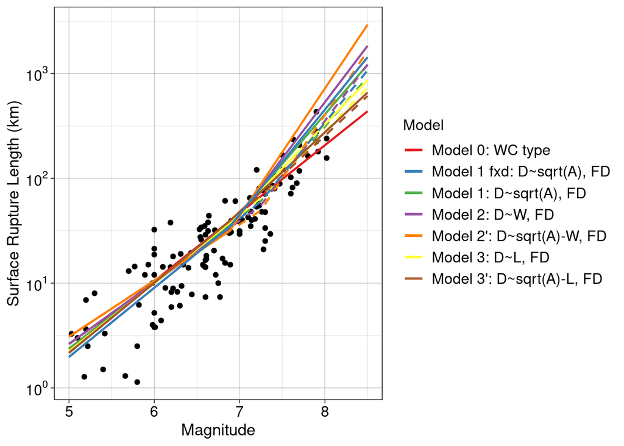

Figure 6. Prediction of candidate SRL Models for Strike-slip events with a 15km and 20km width of seismogenic zone

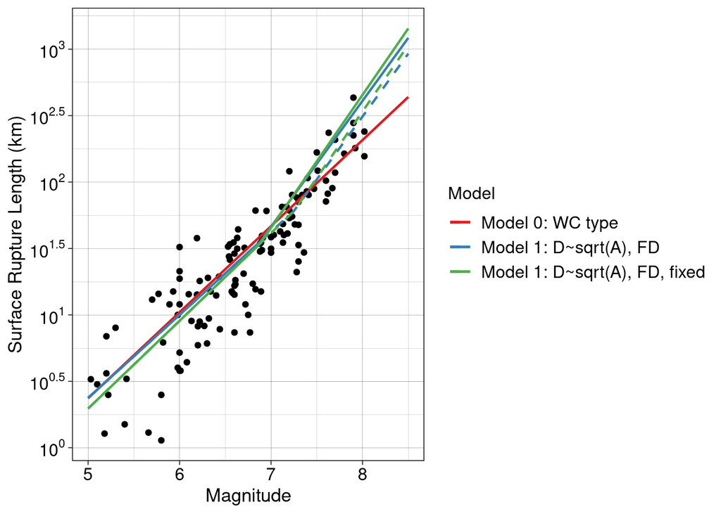

Figure 7. Prediction of SRL model 1 for Strike-slip events with a 15km and 20km width of seismogenic zone

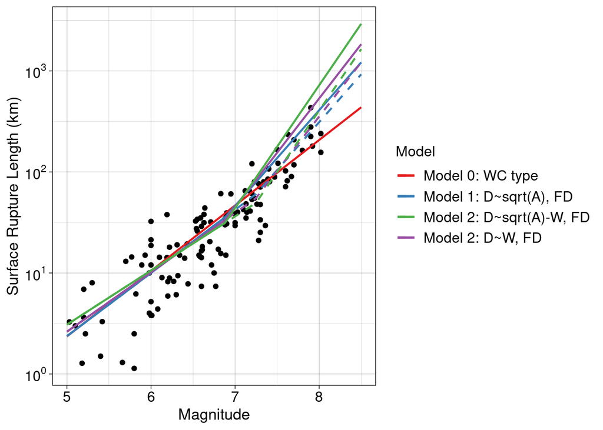

Figure 8. Prediction of SRL model 2 for Strike-slip events with a 15km and 20km width of seismogenic zone

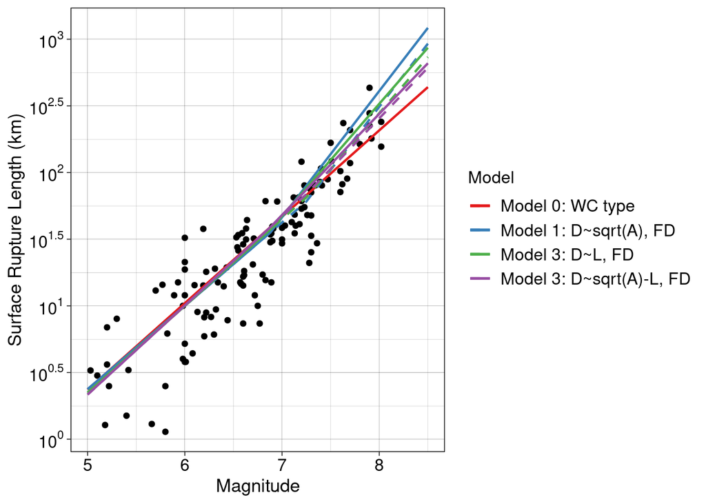

Figure 9. Prediction of SRL model 3 for Strike-slip events with a 15km and 20km width of seismogenic zone

Figure 10 presents the predictions of `model 1 fxd` (preferred model) for the same Strike-slip events with a $15 km$ and $20 km$ width of seismogenic zone.

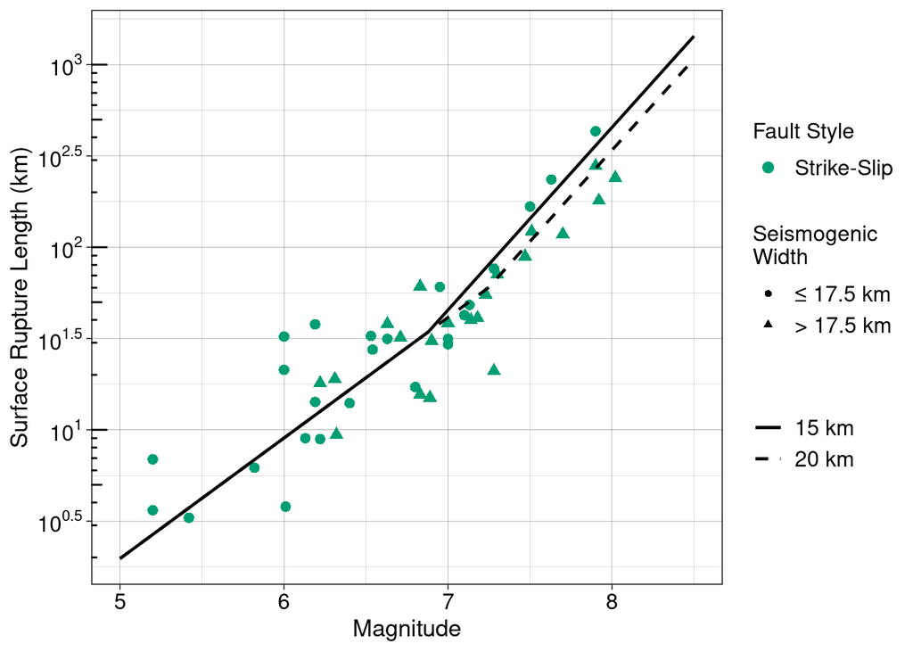

Figure 10. Prediction of preferred SRL Model for Strike-slip events with a 15km and 20km width of seismogenic zone

Figure 11 presents the predictions of `model 1 fxd` for Strike-slip and Dip-slip events with a $15 km$ width of seismogenic zone.

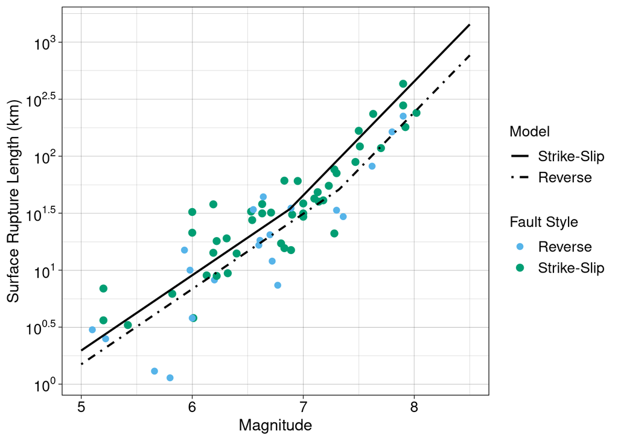

Figure 11. Prediction of preferred SRL Model for Strike-slip and Dip-slip events and 15km width of seismogenic zone

Figure 12 compares the predictions of `model 0` and `model 1 fxd` for Strike-slip events with a $15 km$ and $20 km$ width of seismogenic zone. Both models have similar scaling for unbounded ruptures, but `model 1 fxd` also captures the change in scaling for width-limited ruptures leading to an overall better predictive performance.

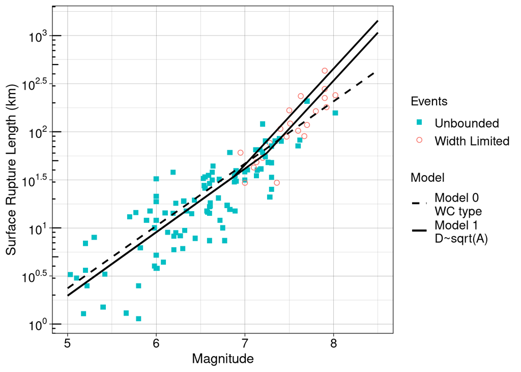

Figure 12. Prediction of Candidate SRL Models for Strike-slip events with a 15km and 20km width of seismogenic zone. Comparison with unbounded and width-limited events

Figure 13 presents the regression residuals versus $\mathbf{M}$ for all candidate $SRL$ models.

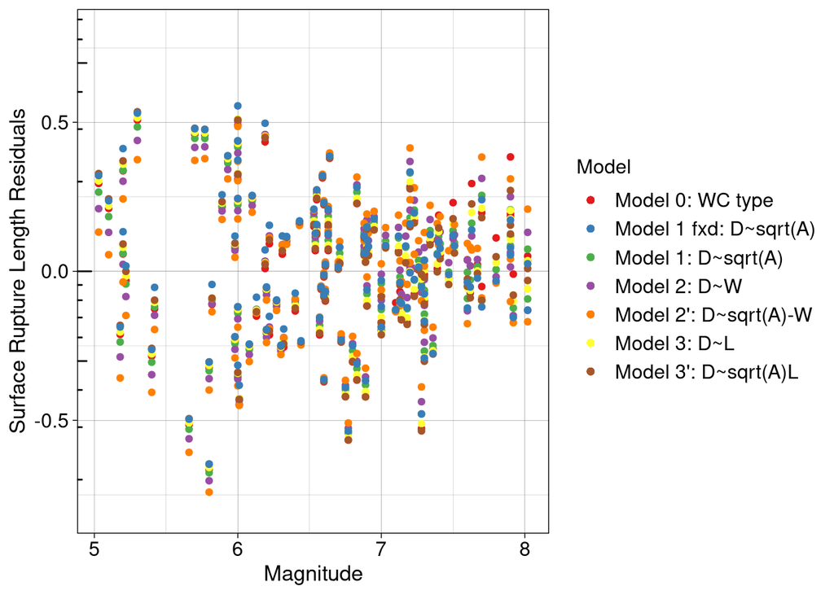

Figure 13. Comparison Residuals of all candidate Models

Figure 14 shows the regression residuals versus magnitude of `model 1 fxd` (preferred model).

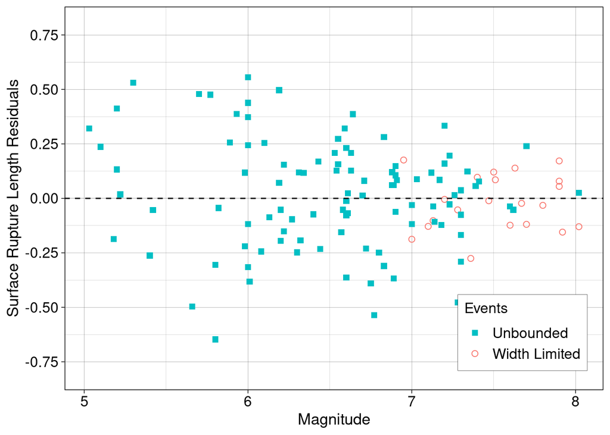

Figure 14. Prefered Model (Model 1, D~sqrt(A), fixed slope) Residuals versus Magnitude

Figure 15 shows the `model 0` regression residuals versus magnitude.

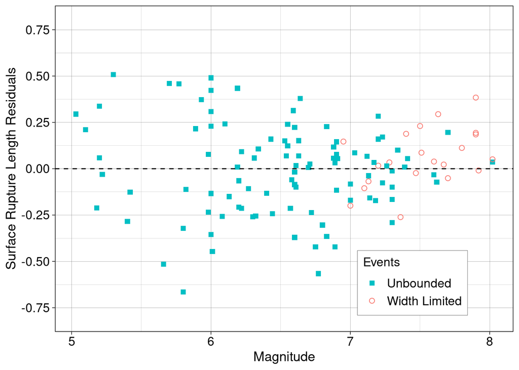

Figure 15. Linear model (Model 0, WC type) Residuals versus Magnitude

Figure 16 shows the `model 1` regression residuals versus magnitude.

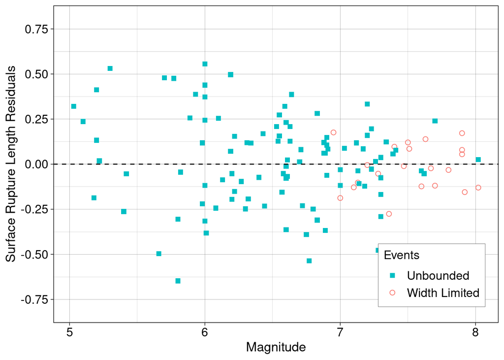

Figure 16. Candidate Model (Model 1, D~sqrt(A)) Residuals versus Magnitude

Figure 17 shows the `model 2` regression residuals versus magnitude.

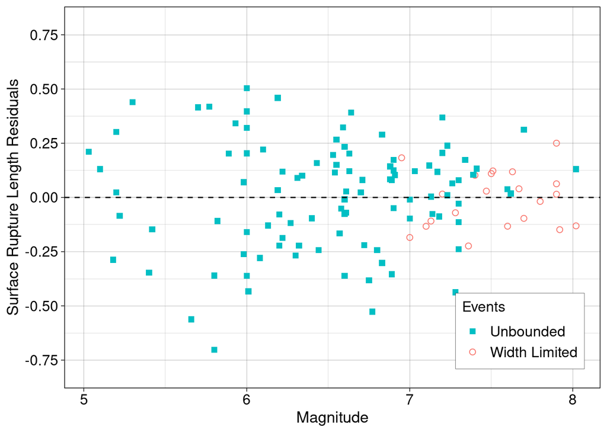

Figure 17. Candidate Model (Model 2, D~W) Residuals versus Magnitude

Figure 18 shows the `model 3` regression residuals versus magnitude.

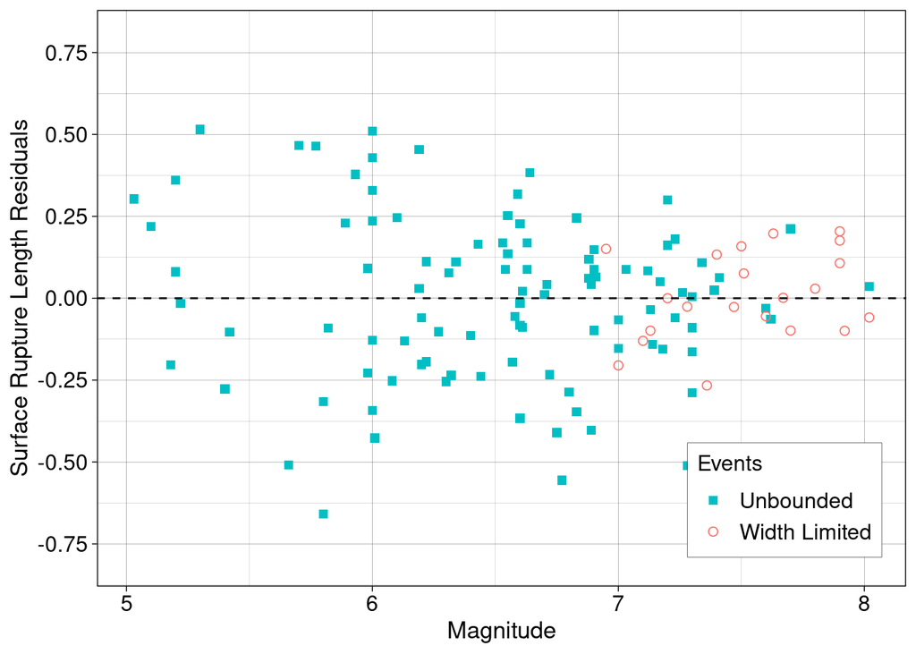

Figure 18. Candidate Model (Model 3, D~L) Residuals versus Magnitude

Figure 19 shows the `model 2'` regression residuals versus magnitude.

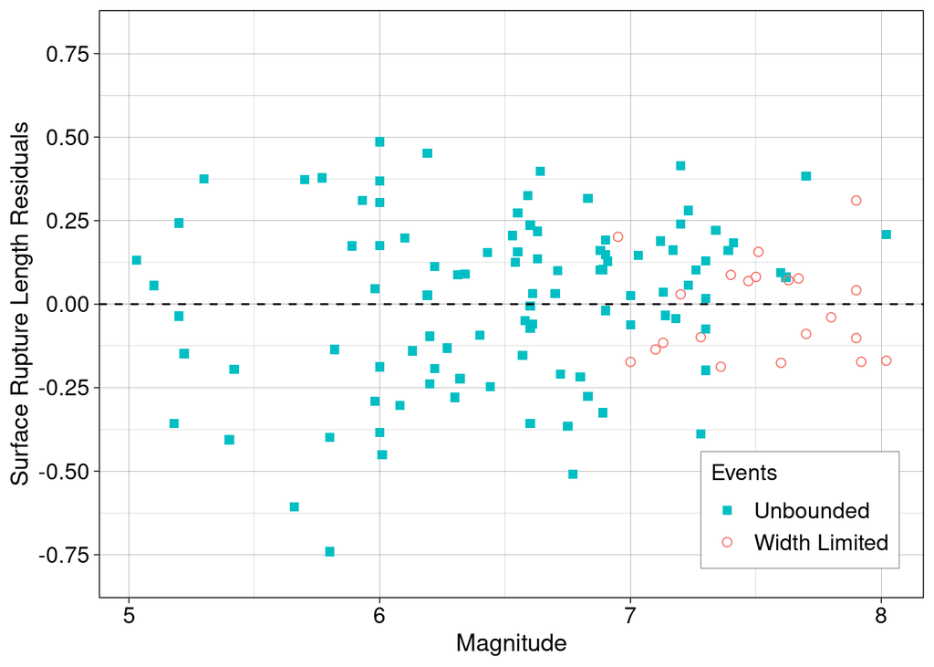

Figure 20 shows the `model 3'` regression residuals versus magnitude.

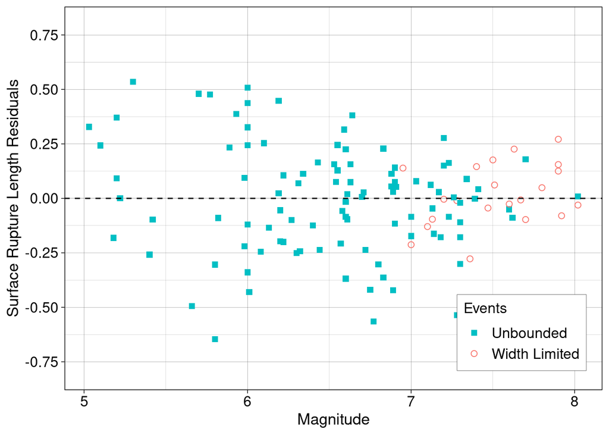

Figure 20. Candidate Model (Model 3’, D~sqrt(A)-L) Residuals versus Magnitude

Figure 21 compares the residuals for the regression models that use the model 1 functional from with and without a fixed slope.

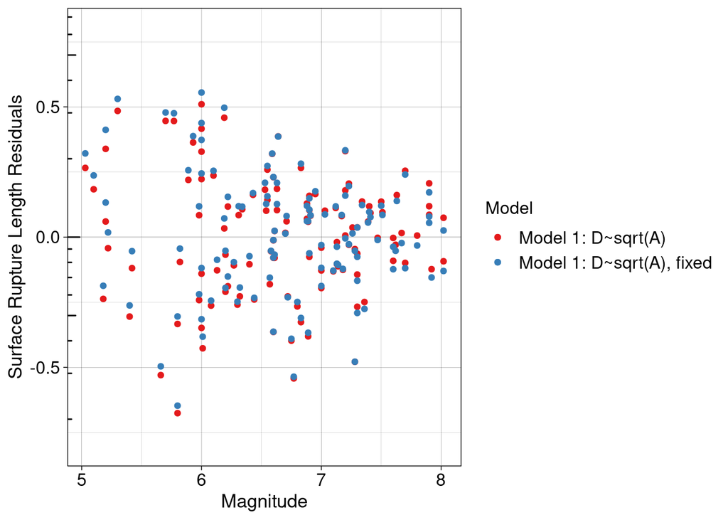

Figure 21. Comparison Residuals of model 1 functional form models

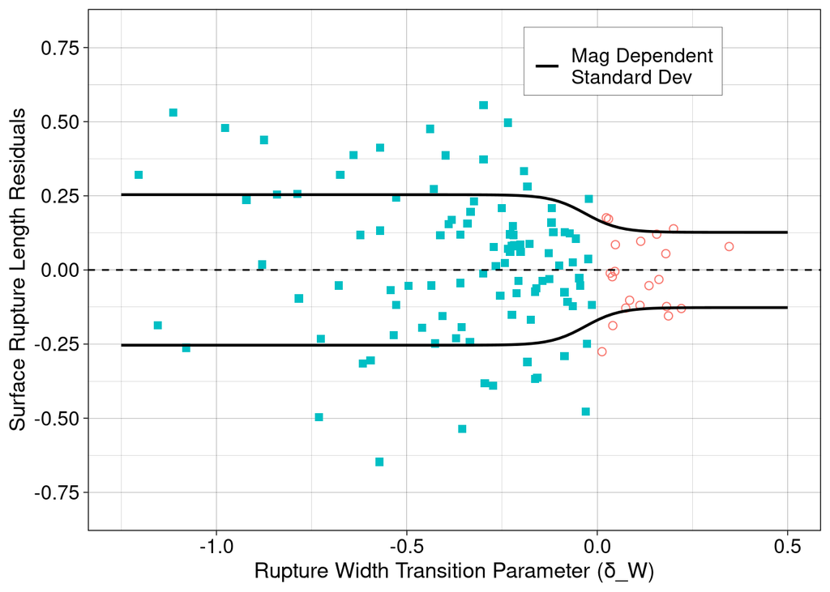

Figure 22 Prefered Model (Model 1, D~sqrt(A), fixed slope) Residuals versus Width transition

### Comparison With Existing Models

Figure 23 compares the preferred model with existing $SLR$ relationships. WC94 All and WC94 SS correspond to the Wells and Coppersmith (1994) $SRL ~ \mathbf{M}$ scaling relationships for All types of slip and Strike-slip events. WY15 OLS and WY15 Deming correspond to the Wells and Youngs (2015) $SRL ~ \mathbf{M}$ scaling relationships using ordinary-least-squares and errors-in-variables regression models. L10 DS, L10 SS, and L10 SRC correspond to the Leonard (2010) $SRL ~ \mathbf{M}$ scaling relationships for Dip-slip, Strike-slip, and Stable-Continental events. The proposed model is in agreement with the existing models over different magnitude ranges. It is in good agreement with the Leonard (2010) scaling relationship for small to moderate size events, and in good agreement with the Wells and Coppersmith (1994) and Wells and Youngs (2015) scaling relationships at large size events. A potential reason for the agreement at different magnitude ranges is that the dataset used by Leonard (2010) was primarily composed of events ranging from $\mathbf{M}~5$ to $7$, while datasets used by Wells and Coppersmith (1994) and Wells and Youngs (2015) was primarily composed of events ranging from $\mathbf{M}~6$ to $7.8$.

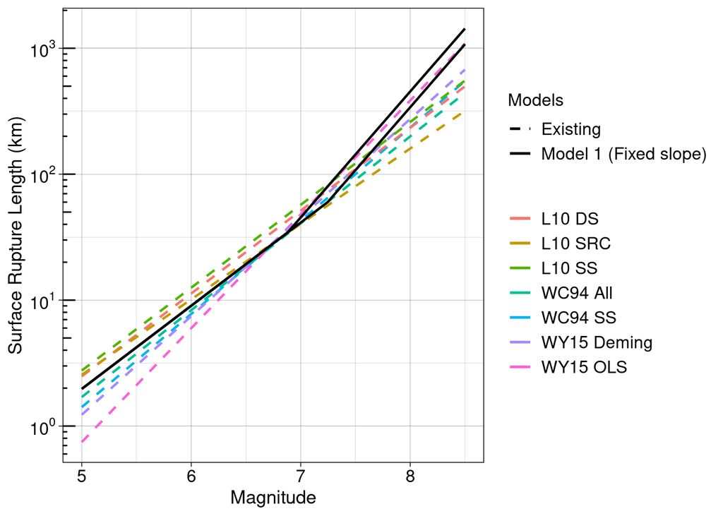

Figure 23. Comparison Preferred Model (Model 1, D~sqrt(A)) with existing SLR relationships

## Acknowledgements

- Alexandra Sarmiento (discussions & comments)
- Stephane Baize (data)

## References

Baize, S., O. Scotti, J.-F. Ritz, M. Ferry, C. Larroque, E. Mathot, L. Audin, F. Nurminen, P. Boncio, and B. Delouis (2020). Surface ruptures during moderate earthquakes: Is that so rare? Geological Society of America 2020 Connects Online

Bodin, P., and J. N. Brune (1996). On the scaling of slip with rupture length for shallow strike-slip earthquakes: Quasistatic models and dynamic rupture propagation, Bull. Seismol. Soc. Am. 86, 1292.

Hanks, T. C., & Bakun, W. H. (2002). A bilinear source-scaling model for M-log A observations of continental earthquakes. Bulletin of the Seismological Society of America, 92(5), 1841-1846.

Leonard, M. (2010). Earthquake fault scaling: Self-consistent relating of rupture length, width, average displacement, and moment release. Bulletin of the Seismological Society of America, 100(5A), 1971-1988.

Romanowicz, B. (1992). Strike‐slip earthquakes on quasi‐vertical transcurrent faults: Inferences for general scaling relations. Geophysical Research Letters, 19(5), 481-484.

Romanowicz, B. (1994). Comment on “A reappraisal of large earthquake scaling” by C. Scholz. Bulletin of the Seismological Society of America, 84(5), 1675-1676.

Romanowicz, B., & Rundle, J. B. (1993). On scaling relations for large earthquakes. Bulletin of the Seismological Society of America, 83(4), 1294-1297.

Pegler, G., & Das, S. (1996). Analysis of the relationship between seismic moment and fault length for large crustal strike‐slip earthquakes between 1977–92. Geophysical research letters, 23(9), 905-908.

Scholz, C. H. (1982). Scaling laws for large earthquakes: consequences for physical models. Bulletin of the Seismological Society of America, 72(1), 1-14.

Scholz, C. H. (1994). A reappraisal of large earthquake scaling. Bulletin of the Seismological Society of America, 84(1), 215-218.

Scholz, C. H. (1997). Size distributions for large and small earthquakes. Bulletin of the Seismological Society of America, 87(4), 1074-1077.

Scholz, C. H. (1998). A further note on earthquake size distributions. Bulletin of the Seismological Society of America, 88(5), 1325-1326.

Wang, Y., & Goulet, C. (2021). Validation of fault displacements from dynamic rupture simulations against the observations from the 1992 landers earthquake. Bulletin of the Seismological Society of America, 111(5), 2574-2594.

Wells, D. L., & Coppersmith, K. J. (1994). New empirical relationships among magnitude, rupture length, rupture width, rupture area, and surface displacement. Bulletin of the seismological Society of America, 84(4), 974-1002.

Wells, D. L., & Youngs R. B. (2015). Improved Regression Relations for Earthquake Source Parameters. Seismological Society of America 2015 Annual Meeting